# C8 Week 2

JAGV

2026-01-13

# The Caret Package

```r
#install.packages("caret", dependencies = TRUE)
#library(caret)
```

## Machine learning algorithms in R

- Linear discriminant analysis
- Regression
- Naive Bayes
- Support Vector Machines
- Classification and regression trees
- Random forests
- Boosting
- among others

```r
library(caret)
library(kernlab)
data(spam)

inTrain <- createDataPartition(y = spam$type, p = 0.75, list = FALSE)
training <- spam[inTrain,]
testing <- spam[-inTrain,]
dim(training)
```

```
## [1] 3451   58
```

```r
dim(testing)
```

```
## [1] 1150   58
```

This is an example of how to split data. Now, we can fit a model

```r
set.seed(32343)
modelFit <- train(type ~., data = training, method = "glm")
modelFit
```

```
## Generalized Linear Model
##
## 3451 samples
##   57 predictor
##    2 classes: 'nonspam', 'spam'
##
## No pre-processing
## Resampling: Bootstrapped (25 reps)
## Summary of sample sizes: 3451, 3451, 3451, 3451, 3451, 3451, ...
## Resampling results:
##
##   Accuracy   Kappa
##   0.9157704  0.8241201
```

We can take a look at the final model:

```r
modelFit$finalModel
```

```
##
## Call:  NULL
##
## Coefficients:
##       (Intercept)               make            address                all
##        -1.417e+00         -3.575e-01         -1.427e-01          7.983e-02
##             num3d                our               over             remove
##         1.747e+00          5.567e-01          5.033e-01          1.871e+00
##          internet              order               mail            receive
##         8.147e-01          1.243e+00          1.270e-01         -3.833e-02
##              will             people             report          addresses
##        -1.583e-01         -1.722e-02          2.915e-02          1.275e+00
##              free           business              email                you
##         1.215e+00          9.706e-01          5.749e-02          7.110e-02
##            credit               your               font             num000
##         1.654e+00          2.009e-01          1.150e-01          1.547e+00
##             money                 hp                hpl             george
##         6.804e-01         -1.760e+00         -1.271e+00         -1.170e+01
##            num650                lab               labs             telnet
##         3.793e-01         -4.178e+00         -4.055e-01          4.273e-01
##            num857               data             num415              num85
##         3.488e+00         -1.032e+00          5.977e-01         -2.342e+00
##        technology            num1999              parts                 pm
##         7.924e-01          1.870e-02         -7.537e-01         -9.356e-01
##            direct                 cs            meeting           original
##        -4.046e-01         -5.589e+02         -2.925e+00         -2.253e+00
##           project                 re                edu              table
##        -1.295e+00         -8.149e-01         -2.149e+00         -2.214e+00
##        conference      charSemicolon   charRoundbracket  charSquarebracket
##        -3.848e+00         -1.198e+00         -1.520e-01         -9.531e-01
##   charExclamation         charDollar           charHash         capitalAve
##         2.996e-01          4.734e+00          2.554e+00          1.689e-02
##       capitalLong       capitalTotal
##         7.250e-03          1.197e-03
##
## Degrees of Freedom: 3450 Total (i.e. Null);  3393 Residual
## Null Deviance:       4628
## Residual Deviance: 1379  AIC: 1495
```

and also make predictions

```r
predictions <- predict(modelFit, newdata = testing)
predictions
```

```
##    [1] spam    spam    spam    spam    spam    spam    nonspam nonspam spam
##   [10] spam    nonspam spam    spam    spam    spam    spam    nonspam spam
##   [19] spam    spam    spam    spam    spam    spam    spam    spam    spam
##   [28] nonspam spam    spam    nonspam spam    spam    spam    spam    nonspam
##   [37] spam    spam    spam    spam    spam    spam    spam    spam    spam
##   [46] spam    spam    spam    spam    spam    spam    spam    spam    spam
##   [55] spam    spam    spam    spam    spam    spam    spam    spam    spam
##   [64] spam    spam    spam    spam    spam    spam    spam    nonspam spam
##   [73] spam    spam    nonspam spam    spam    spam    spam    nonspam spam
##   [82] spam    spam    spam    spam    spam    spam    spam    spam    spam
##   [91] spam    spam    spam    spam    spam    spam    spam    spam    spam
##  [100] spam    spam    spam    spam    spam    spam    spam    spam    spam
##  [109] nonspam spam    nonspam spam    spam    spam    spam    spam    spam
##  [118] spam    spam    spam    spam    spam    spam    spam    spam    nonspam
##  [127] spam    spam    spam    spam    spam    spam    spam    spam    spam
```

[output cut: 114 more lines]

```r
confusionMatrix(predictions, testing$type)
```

```
## Confusion Matrix and Statistics
##
##           Reference
## Prediction nonspam spam
##    nonspam     660   40
##    spam         37  413
##
##                Accuracy : 0.933
##                  95% CI : (0.917, 0.9468)
##     No Information Rate : 0.6061
##     P-Value [Acc > NIR] : <2e-16
##
##                   Kappa : 0.8596
##
##  Mcnemar's Test P-Value : 0.8197
##
##             Sensitivity : 0.9469
##             Specificity : 0.9117
##          Pos Pred Value : 0.9429
##          Neg Pred Value : 0.9178
##              Prevalence : 0.6061
##          Detection Rate : 0.5739
##    Detection Prevalence : 0.6087
##       Balanced Accuracy : 0.9293
##
##        'Positive' Class : nonspam
##
```

# Data slicing

We can create data partition using the function `createDataPartition` in order to split data into training and testing sets. This is helpful in cross validation for instance.

```r
library(caret)
library(kernlab)
data(spam)

inTrain <- createDataPartition(y = spam$type, p = 0.75, list = FALSE)
training <- spam[inTrain,]
testing <- spam[-inTrain,]
dim(training)
```

```
## [1] 3451   58
```

We can also create K-folds:

```r
set.seed(32323, sample.kind = "Rounding")
folds <- createFolds(y = spam$type, k = 10, list = TRUE, returnTrain = TRUE)
sapply(folds,length)
```

```
## Fold01 Fold02 Fold03 Fold04 Fold05 Fold06 Fold07 Fold08 Fold09 Fold10
##   4141   4140   4141   4142   4140   4142   4141   4141   4140   4141
```

```r
folds[[1]][1:10]
```

```
##  [1]  1  2  3  4  5  6  7  8  9 10
```

```r
set.seed(32323, sample.kind = "Rounding")
folds <- createFolds(y = spam$type, k = 10, list = TRUE, returnTrain = FALSE)
sapply(folds,length)
```

```
## Fold01 Fold02 Fold03 Fold04 Fold05 Fold06 Fold07 Fold08 Fold09 Fold10
##    460    461    460    459    461    459    460    460    461    460
```

```r
folds[[1]][1:10]
```

```
##  [1] 24 27 32 40 41 43 55 58 63 68
```

Resampling

```r
set.seed(32323, sample.kind = "Rounding")
folds <- createResample(y = spam$type, times = 10, list = TRUE)
sapply(folds,length)
```

```
## Resample01 Resample02 Resample03 Resample04 Resample05 Resample06 Resample07
##       4601       4601       4601       4601       4601       4601       4601
## Resample08 Resample09 Resample10
##       4601       4601       4601
```

```r
folds[[1]][1:10]
```

```
##  [1]  1  2  3  3  3  5  5  7  8 12
```

Time slices

```r
set.seed(32323, sample.kind = "Rounding")
tiempo <- 1:1000
folds <- createTimeSlices(y = tiempo, initialWindow = 20, horizon = 10)
names(folds)
```

```
## [1] "train" "test"
```

```r
folds$train[[1]]
```

```
##  [1]  1  2  3  4  5  6  7  8  9 10 11 12 13 14 15 16 17 18 19 20
```

```r
folds$test[[1]]
```

```
##  [1] 21 22 23 24 25 26 27 28 29 30
```

# Training options

```r
library(caret)
library(kernlab)
data(spam)

inTrain <- createDataPartition(y = spam$type, p = 0.75, list = FALSE)
training <- spam[inTrain,]
testing <- spam[-inTrain,]

modelFit <- train(type ~., data = training, method = "glm")

args(train)
```

```
## function (x, ...)
## NULL
```

Among the metric options are:

- Continuous outcomes:
  - RMSE
  - R-Squared from regression models
- Categorical outcomes:
  - Accuraccy -> Fraction correct
  - Kappa -> A measure of concordance.

```r
args(trainControl)
```

```
## function (method = "boot", number = ifelse(grepl("cv", method),
##     10, 25), repeats = ifelse(grepl("[d_]cv$", method), 1, NA),
##     p = 0.75, search = "grid", initialWindow = NULL, horizon = 1,
##     fixedWindow = TRUE, skip = 0, verboseIter = FALSE, returnData = TRUE,
##     returnResamp = "final", savePredictions = FALSE, classProbs = FALSE,
##     summaryFunction = defaultSummary, selectionFunction = "best",
##     preProcOptions = list(thresh = 0.95, ICAcomp = 3, k = 5,
##         freqCut = 95/5, uniqueCut = 10, cutoff = 0.9), sampling = NULL,
##     index = NULL, indexOut = NULL, indexFinal = NULL, timingSamps = 0,
##     predictionBounds = rep(FALSE, 2), seeds = NA, adaptive = list(min = 5,
##         alpha = 0.05, method = "gls", complete = TRUE), trim = FALSE,
##     allowParallel = TRUE)
## NULL
```

Function `trainControl`

- Method
  - *boot*: bootstrapping
  - *boot632*: bootstrapping with adjustment
  - *cv*: Cross-validation
  - *repeatedcv*: repeated cross-validation
  - *LOOCV*: Leave one out cross-validation
- Number
  - For boot/cross validation
  - Number of subsamples to take
- repeats
  - Number of times to repeate subsampling
  - If big this can slow things down

```r
set.seed(1235)
modelFit2 <- train(type ~., data = training, method = "glm")
modelFit2
```

```
## Generalized Linear Model
##
## 3451 samples
##   57 predictor
##    2 classes: 'nonspam', 'spam'
##
## No pre-processing
## Resampling: Bootstrapped (25 reps)
## Summary of sample sizes: 3451, 3451, 3451, 3451, 3451, 3451, ...
## Resampling results:
##
##   Accuracy   Kappa
##   0.9091913  0.8095559
```

# Plotting predictors

Example: Predicting wages

```r
library(ISLR)
library(ggplot2)
library(caret)
data(Wage)
summary(Wage)
```

```
##       year           age                     maritl           race
##  Min.   :2003   Min.   :18.00   1. Never Married: 648   1. White:2480
##  1st Qu.:2004   1st Qu.:33.75   2. Married      :2074   2. Black: 293
##  Median :2006   Median :42.00   3. Widowed      :  19   3. Asian: 190
##  Mean   :2006   Mean   :42.41   4. Divorced     : 204   4. Other:  37
##  3rd Qu.:2008   3rd Qu.:51.00   5. Separated    :  55
##  Max.   :2009   Max.   :80.00
##
##               education                     region               jobclass
##  1. < HS Grad      :268   2. Middle Atlantic   :3000   1. Industrial :1544
##  2. HS Grad        :971   1. New England       :   0   2. Information:1456
##  3. Some College   :650   3. East North Central:   0
##  4. College Grad   :685   4. West North Central:   0
##  5. Advanced Degree:426   5. South Atlantic    :   0
##                           6. East South Central:   0
##                           (Other)              :   0
##             health      health_ins      logwage           wage
##  1. <=Good     : 858   1. Yes:2083   Min.   :3.000   Min.   : 20.09
##  2. >=Very Good:2142   2. No : 917   1st Qu.:4.447   1st Qu.: 85.38
##                                      Median :4.653   Median :104.92
##                                      Mean   :4.654   Mean   :111.70
##                                      3rd Qu.:4.857   3rd Qu.:128.68
##                                      Max.   :5.763   Max.   :318.34
##
```

```r
inTrain <- createDataPartition(y = Wage$wage, p = 0.7, list = FALSE)
training <- Wage[inTrain,]
test <- Wage[-inTrain,]
dim(training)
```

```
## [1] 2102   11
```

```r
dim(testing)
```

```
## [1] 1150   58
```

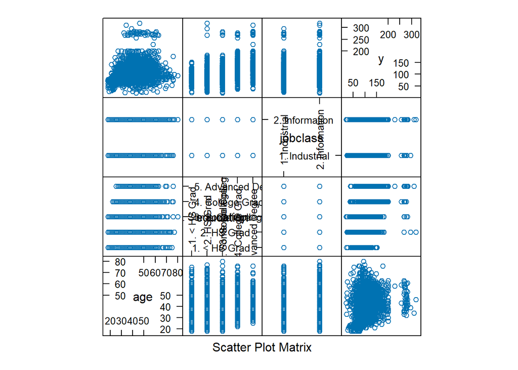

```r
featurePlot(x = training[,c("age", "education", "jobclass")],y = training$wage, plot = "pairs")
```

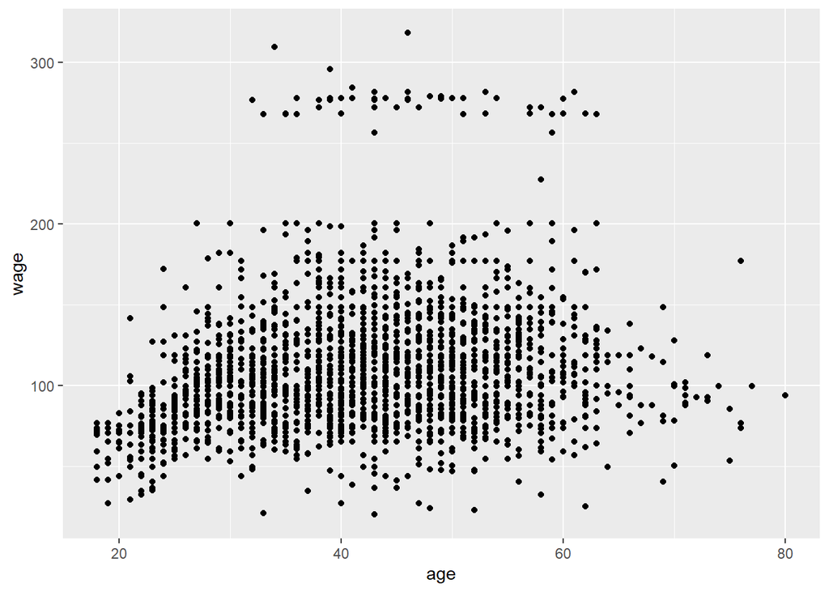

```r
qplot(age,wage, data = training)
```

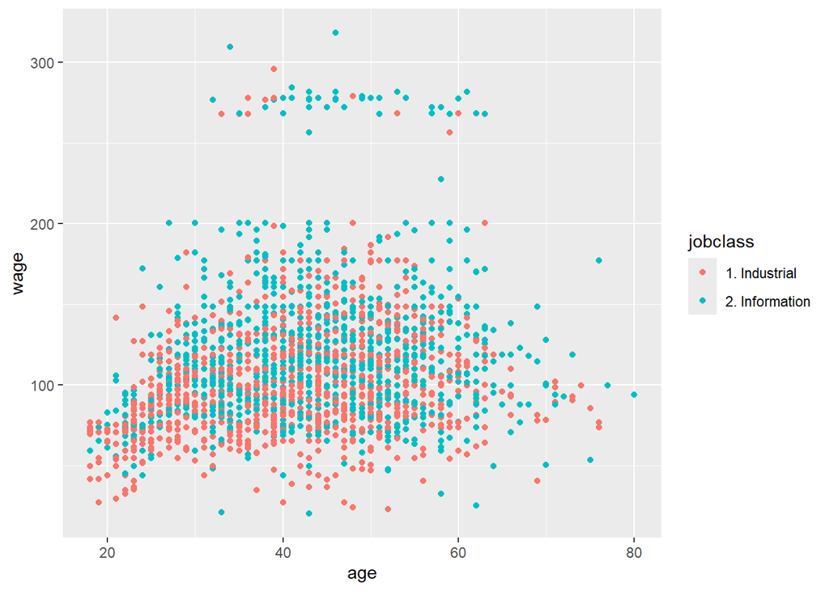

```r
qplot(age, wage, data = training, colour = jobclass)
```

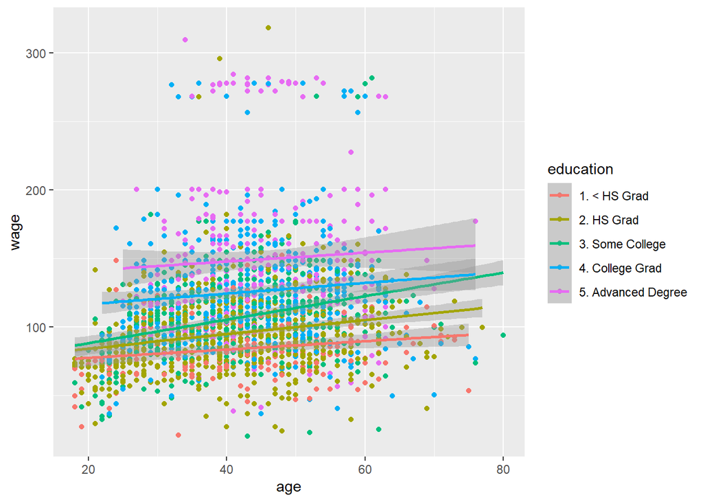

```r
qq <- qplot(age, wage, colour = education, data = training)
qq + geom_smooth(method = "lm", formula = y~x)
```

We can use the `cut` function to make factors. This function is included in `Hmisc` R package.

```r
library(Hmisc)
library(gridExtra)
cutWage <- cut2(training$wage, g = 3)
table(cutWage)
```

```
## cutWage
## [ 20.1, 91.7) [ 91.7,118.9) [118.9,318.3]
##           702           731           669
```

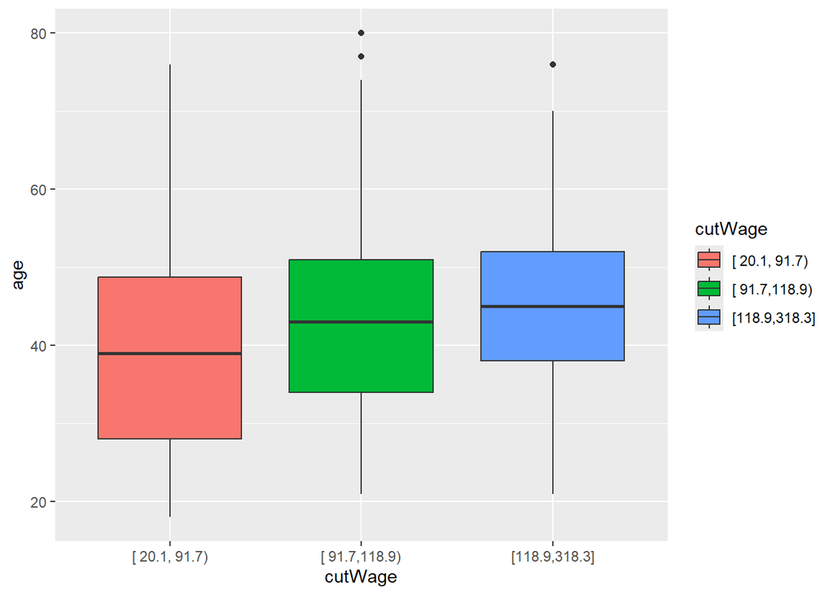

```r
p1 <- qplot(cutWage, age, data = training, fill = cutWage, geom = c("boxplot"))
p1
```

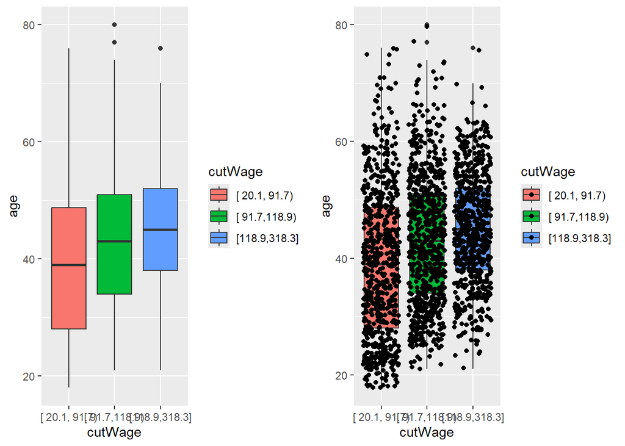

```r
p2 <- qplot(cutWage, age, data = training, fill = cutWage, geom = c("boxplot", "jitter"))
grid.arrange(p1,p2,ncol = 2)
```

We can create tables

```r
t1 <- table(cutWage, training$jobclass)
t1
```

```
##
## cutWage         1. Industrial 2. Information
##   [ 20.1, 91.7)           442            260
##   [ 91.7,118.9)           378            353
##   [118.9,318.3]           258            411
```

```r
### Use number 1 for row-wise proportion.
prop.table(t1,1)
```

```
##
## cutWage         1. Industrial 2. Information
##   [ 20.1, 91.7)     0.6296296      0.3703704
##   [ 91.7,118.9)     0.5170999      0.4829001
##   [118.9,318.3]     0.3856502      0.6143498
```

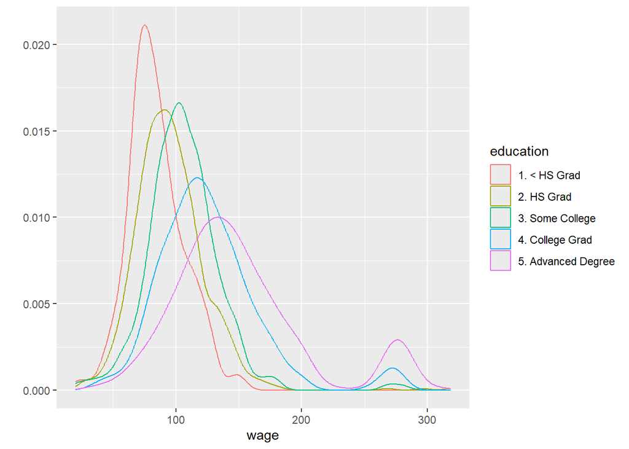

```r
qplot(wage, colour = education, data = training, geom ="density")
```

Do not forget:

- Make your plots only **in the training set**: don’t use the test set for exploration.
- Things you should be looking for:
  - Imbalance in outcomes/predictors
  - Outliers
  - Groups of points not explained by a predictor
  - Skewed variables

# Preprocessing

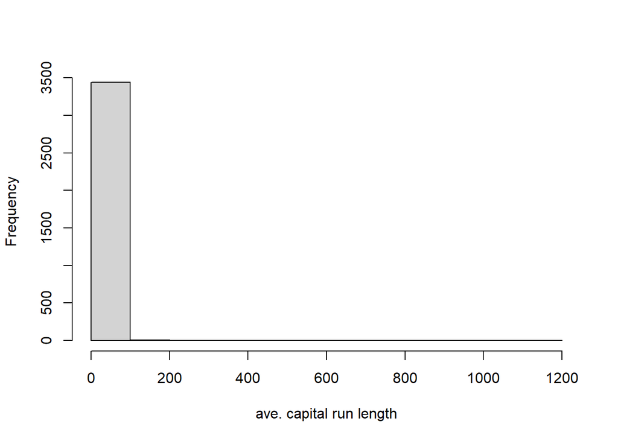

```r
library(caret)
library(kernlab)
data(spam)
inTrain <- createDataPartition(y = spam$type, p = 0.75, list = FALSE)

training <- spam[inTrain,]
testing <- spam[-inTrain,]
hist(training$capitalAve, main = "", xlab = "ave. capital run length")
```

```r
mean(training$capitalAve)
```

```
## [1] 5.011624
```

```r
sd(training$capitalAve)
```

```
## [1] 32.20408
```

This is a **very skewed** data. We can standardize. We can do it *manually* or use a function from the `caret` package, as it is shown in the following chunk.

```r
trainCapAve <- training$capitalAve
trainCapAveS <- (trainCapAve - mean(trainCapAve))/sd(trainCapAve)
c(mean(trainCapAveS), sd(trainCapAveS))
```

```
## [1] -1.592408e-18  1.000000e+00
```

```r
## Applied to the test set
testCapAve <- testing$capitalAve
testCapAveS <- (testCapAve - mean(trainCapAve))/sd(trainCapAve)
c(mean(testCapAveS), sd(testCapAveS))
```

```
## [1] 0.02234876 0.93987023
```

```r
## Using the caret function
preObj <- preProcess(training[,-58], method = c("center", "scale"))
trainCapAveS <- predict(preObj, training[,-58])$capitalAve
c(mean(trainCapAveS), sd(trainCapAveS))
```

```
## [1] -1.592408e-18  1.000000e+00
```

```r
testCapAveS <- predict(preObj, testing[,-58],)$capitalAve
c(mean(testCapAveS), sd(testCapAveS))
```

```
## [1] 0.02234876 0.93987023
```

```r
set.seed(32343)
modelFit <- train(type ~., data = training, preProcess = c("center", "scale"), method = "glm")
modelFit
```

```
## Generalized Linear Model
##
## 3451 samples
##   57 predictor
##    2 classes: 'nonspam', 'spam'
##
## Pre-processing: centered (57), scaled (57)
## Resampling: Bootstrapped (25 reps)
## Summary of sample sizes: 3451, 3451, 3451, 3451, 3451, 3451, ...
## Resampling results:
##
##   Accuracy   Kappa
##   0.9151735  0.8221591
```

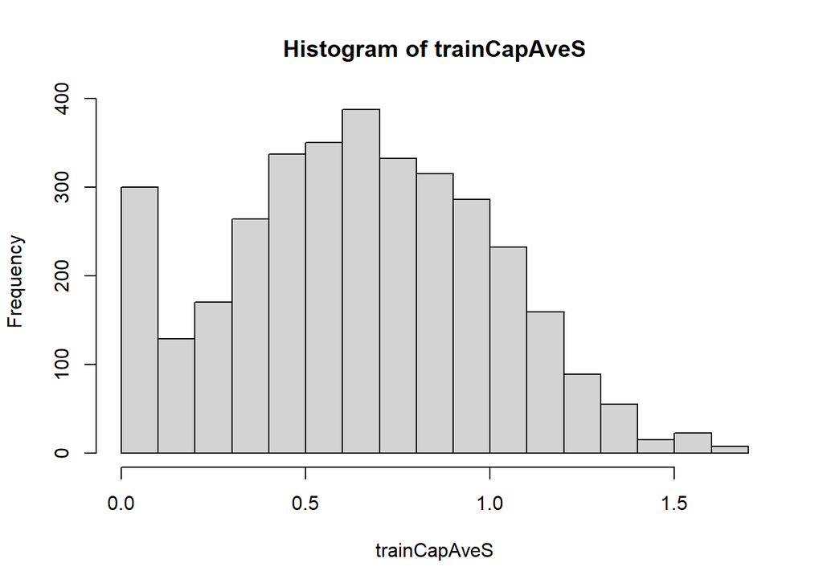

```r
preObj <- preProcess(training[,-58], method = c("BoxCox"))
trainCapAveS <- predict(preObj, training[,-58])$capitalAve
hist(trainCapAveS)
```

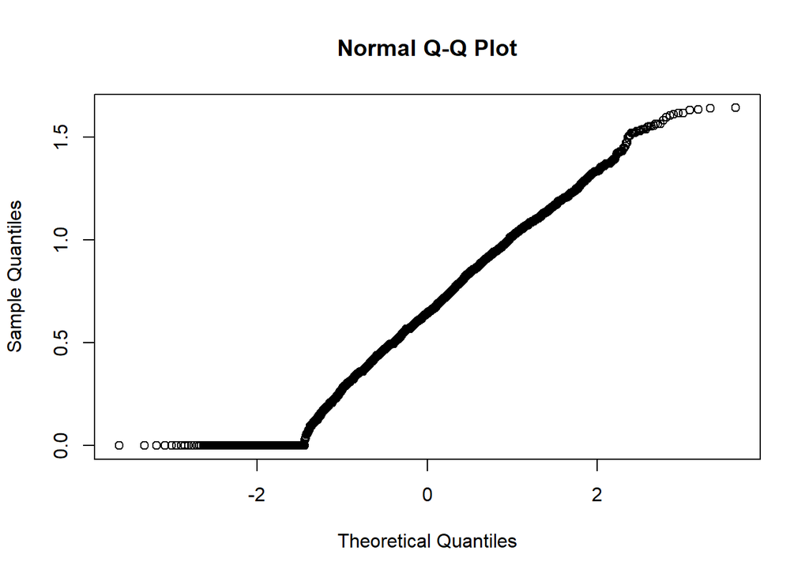

```r
qqnorm(trainCapAveS)
```

## Standardizing - Imputing data

```r
set.seed(13343, sample.kind = "Rounding")
#Make some values NA
training$capAve <- training$capitalAve
selectNA <- rbinom(dim(training)[1], size = 1, prob = 0.05)==1
training$capAve[selectNA] <- NA

# Impute and standardize
preObj <- preProcess(training[,-58], method = "knnImpute")
capAve <- predict(preObj, training[,-58])$capAve

# Standardize true values
capAveTruth <- training$capitalAve
capAveTruth <- (capAveTruth - mean(capAveTruth))/sd(capAveTruth)

quantile(capAve - capAveTruth)
```

```
##           0%          25%          50%          75%         100%
## -0.946804216  0.003625242  0.003778011  0.004110527  1.991575570
```

```r
quantile((capAve - capAveTruth)[selectNA])
```

```
##           0%          25%          50%          75%         100%
## -0.946804216 -0.017199153  0.004042596  0.017801425  1.991575570
```

```r
quantile((capAve - capAveTruth)[!selectNA])
```

```
##          0%         25%         50%         75%        100%
## 0.003507144 0.003634127 0.003778011 0.004088262 0.242194882
```

Notes:

- Training and test must be processed in the same way.
- Test transformations will likely be imperfect, especially if the test/training sets collected at different times
- Careful when transforming *factor* variables!

# Covariate creation

Two levels of covariate creation: Level 1 is from raw data to covariates (they could be summary statistics of text, images or websites), and level 2 is transforming tidy covariates.

## Level 1: Raw data -> covariates

When doing this, take into account that:

- Examples of this include:
  - Text files: frequency of words, frequency of phrases, frequency of capital letters, etc.
  - Images: edges, corners, blobs, ridges.
  - Webpages: number and type of images, position of elements, colors, videos.
  - People: Height, weight, hair color, sex, country of origin
- Depends heavily on application.
- The balancing act is summarization vs. information loss
- The more knowledge of the system you have the better the job you will do
- When in doubt, err on the side of more features
- Can be automated, but use caution!

## Level 2: transform tidy covariates

- This is more necessary for some methods (such as regression and support vector machines) than for others (such as classification trees)
- Should be done **only** on the training set
- The best approach is through exploratory data analysis (plotting/tables)
- New covariates should be added to data frames

Let’s take a look at one example:

```r
library(ISLR)
library(caret)
data(Wage)
inTrain <- createDataPartition(y = Wage$wage, p = 0.7, list = FALSE)
training <- Wage[inTrain,]
test <- Wage[-inTrain,]
```

A common practice is to convert qualitative variables into dummy variables

```r
table(training$jobclass)
```

```
##
##  1. Industrial 2. Information
##           1051           1051
```

```r
dummies <- dummyVars(wage ~ jobclass, data = training)
head(predict(dummies, newdata = training))
```

```
##        jobclass.1. Industrial jobclass.2. Information
## 86582                       0                       1
## 161300                      1                       0
## 155159                      0                       1
## 11443                       0                       1
## 376662                      0                       1
## 450601                      1                       0
```

Another common practice is to remove zero covariates

```r
nearzerocovariates <- nearZeroVar(training, saveMetrics = TRUE)
nearzerocovariates
```

```
##            freqRatio percentUnique zeroVar   nzv
## year        1.037356    0.33301618   FALSE FALSE
## age         1.027027    2.85442436   FALSE FALSE
## maritl      3.272931    0.23786870   FALSE FALSE
## race        8.938776    0.19029496   FALSE FALSE
## education   1.389002    0.23786870   FALSE FALSE
## region      0.000000    0.04757374    TRUE  TRUE
## jobclass    1.000000    0.09514748   FALSE FALSE
## health      2.468647    0.09514748   FALSE FALSE
## health_ins  2.352472    0.09514748   FALSE FALSE
## logwage     1.061728   19.17221694   FALSE FALSE
## wage        1.061728   19.17221694   FALSE FALSE
```

Here, we can see that `region` has a near zero variability.

Spline basis can be constructed also:

```r
library(splines)
bsBasis <- bs(training$age, df =3)
bsBasis
```

```
##                   1            2            3
##    [1,] 0.236850055 0.0253767916 9.063140e-04
##    [2,] 0.416337988 0.3211750193 8.258786e-02
##    [3,] 0.430813836 0.2910904300 6.556091e-02
##    [4,] 0.362525595 0.3866939680 1.374912e-01
##    [5,] 0.306334128 0.4241549461 1.957638e-01
##    [6,] 0.424154946 0.3063341278 7.374710e-02
##    [7,] 0.377630828 0.0906313987 7.250512e-03
##    [8,] 0.444358195 0.2275981001 3.885821e-02
##    [9,] 0.442218287 0.1953987782 2.877966e-02
##   [10,] 0.362525595 0.3866939680 1.374912e-01
##   [11,] 0.275519452 0.4362391326 2.302373e-01
##   [12,] 0.444093854 0.2114732637 3.356718e-02
##   [13,] 0.443086838 0.2436977611 4.467792e-02
##   [14,] 0.375000000 0.3750000000 1.250000e-01
```

[output cut: 2098 more lines]

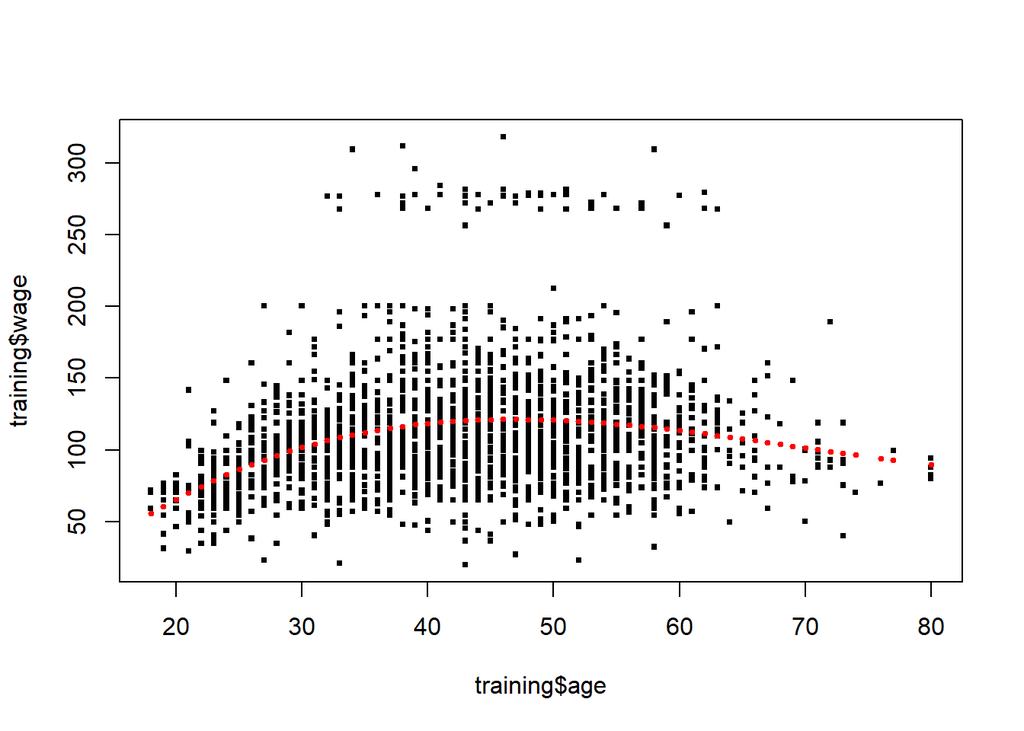

```r
lm1 <- lm(wage ~ bsBasis, data = training)
plot(training$age, training$wage, pch = 15, cex = 0.5)
points(training$age, predict(lm1, newdata = training), col = "red", pch = 19, cex =0.5)
```

Splines on the test set

```r
predict(bsBasis, age = testing$age)
```

```
##                   1            2            3
##    [1,] 0.236850055 0.0253767916 9.063140e-04
##    [2,] 0.416337988 0.3211750193 8.258786e-02
##    [3,] 0.430813836 0.2910904300 6.556091e-02
##    [4,] 0.362525595 0.3866939680 1.374912e-01
##    [5,] 0.306334128 0.4241549461 1.957638e-01
##    [6,] 0.424154946 0.3063341278 7.374710e-02
##    [7,] 0.377630828 0.0906313987 7.250512e-03
##    [8,] 0.444358195 0.2275981001 3.885821e-02
##    [9,] 0.442218287 0.1953987782 2.877966e-02
##   [10,] 0.362525595 0.3866939680 1.374912e-01
##   [11,] 0.275519452 0.4362391326 2.302373e-01
##   [12,] 0.444093854 0.2114732637 3.356718e-02
##   [13,] 0.443086838 0.2436977611 4.467792e-02
##   [14,] 0.375000000 0.3750000000 1.250000e-01
```

[output cut: 2098 more lines]

## Notes and further reading

- Level 1 feature creation (raw data to covariates)
  - Science is key. Advice: (to) google “feature extraction for [data type]”.
  - Err on overcreation of features
  - In some applications (images, voices) automated feature creation is possible/necessary
  - [Deep learning tutorial](https://cs.nyu.edu/~yann/talks/lecun-ranzato-icml2013.pdf)
- Level 2 feature creation (covariates to new covariates)
  - The function `preProcess` in `caret` R-package will handle some preprocessing
  - Create new covariates of you think they will improve the fit
  - Use EDA (Exploratory Data Analysis) on the training set for creating them
  - Be careful about overfitting!
- Preprocessing with caret: [Caret documentation](http://caret.r-forge.r-project.org/preprocess.html)
- In order to fit spline models, use the `gam` method in the `caret` package which allows smoothing of multiple variables

# Preprocessing with PCA

Let’s take a look at **Principal Component Analysis, (PCA)**

### Correlated predictors

```r
library(caret)
library(kernlab)
data(spam)
inTrain <- createDataPartition(y = spam$type, p = 0.75, list = FALSE)

training <- spam[inTrain,]
testing <- spam[-inTrain,]

M <- abs(cor(training[,-58]))
diag(M) <- 0
which(M > 0.8, arr.ind = T)
```

```
##        row col
## num415  34  32
## direct  40  32
## num857  32  34
## direct  40  34
## num857  32  40
## num415  34  40
```

```r
names(spam)[c(32,34,40)]
```

```
## [1] "num857" "num415" "direct"
```

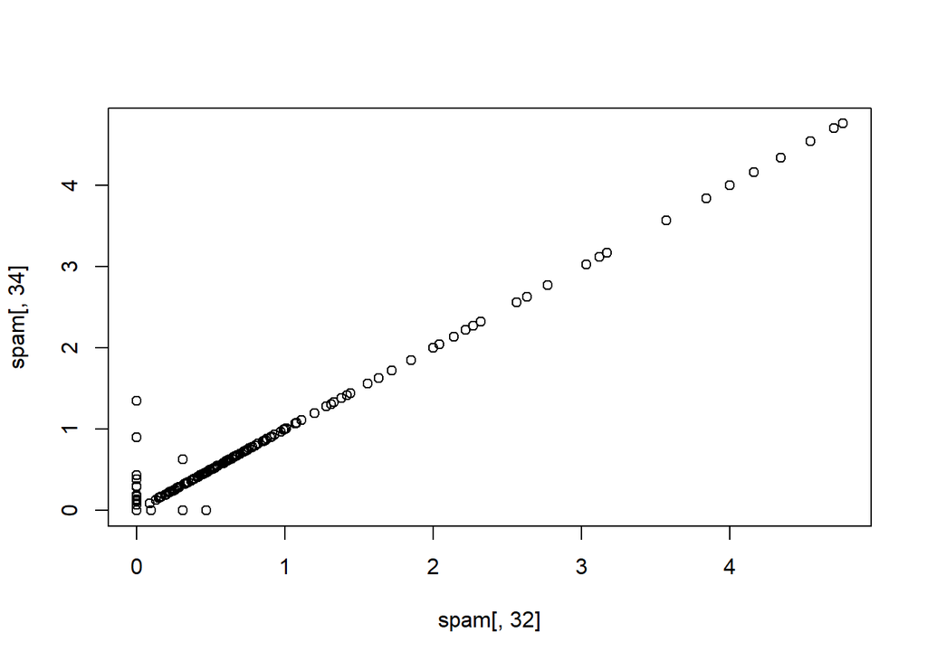

```r
plot(spam[,32], spam[,34])
```

With this, we can see wich variables are highly correlated

### Basic PCA idea

- We might not need every predictor.
- A weighted combination of predictors might be better
- We should pick this combination to capture the *most information* possible
- Benefits:
  - Reduced number of predictors (Okham’s razor?)
  - Reduced noise (due to averaging)

Using linear transformations (rotation matrix) we could rotate the plot

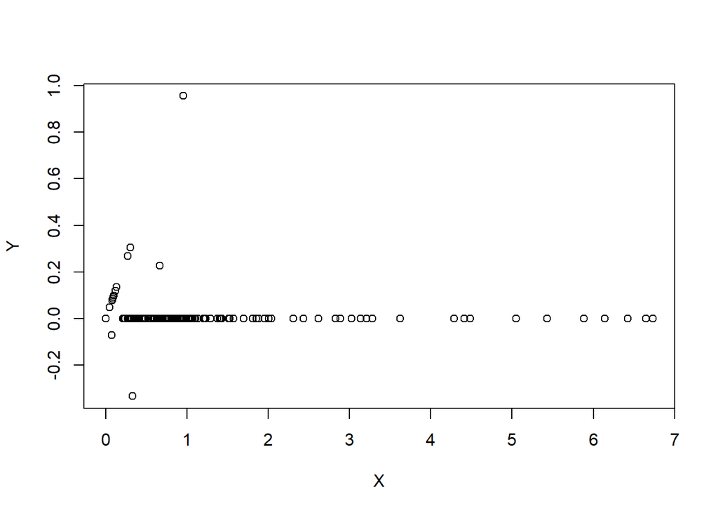

```r
theta <- -pi/4

X <- cos(theta)*training$num857 - sin(theta)*training$num415
Y <- sin(theta)*training$num857 + cos(theta)*training$num415
plot(X,Y)
```

From the plot, $X$ captures more variation than $Y$, so that linear combination should be used

$$X = \left(\frac{1}{\sqrt{2}}\right)\text{num415} +
\left(\frac{1}{\sqrt{2}}\right)\text{num857}$$

### Related problems

You have multivariate variables $X_1, X_2, \dots, X_n$ so $X_1 = \left(X_{11}, \dots, X_{1m}\right)$

- Find a new set of multivariable variables that are **uncorrelated** and explain as much variance as possible
- If you put all the variables together in one matrix, find the best matrix created with fewer variables (**lower rank**) that explains the original data

The first goal is *statistical* and the second goal is *data compression*

### Related solutions - PCA/SVD

#### Singular Value Decomposition (SVD)

If $X$ is a matrix with each variable in a column and each observation in a row then the $SVD$ is a *matrix decomposition*

$$X = UDV^T$$

where the columns of $U$ are orthogonal (left singular vectors), the columns of $V$ are orthogonal (right singular vectors) and $D$ is a diagonal matrix (singular values)

#### Principal Components Analysis (PCA)

The principal components are equal to the right singular values **if** you first scale (substract the mean and divide by the standard deviation) the variables

Let’s take a look at one example

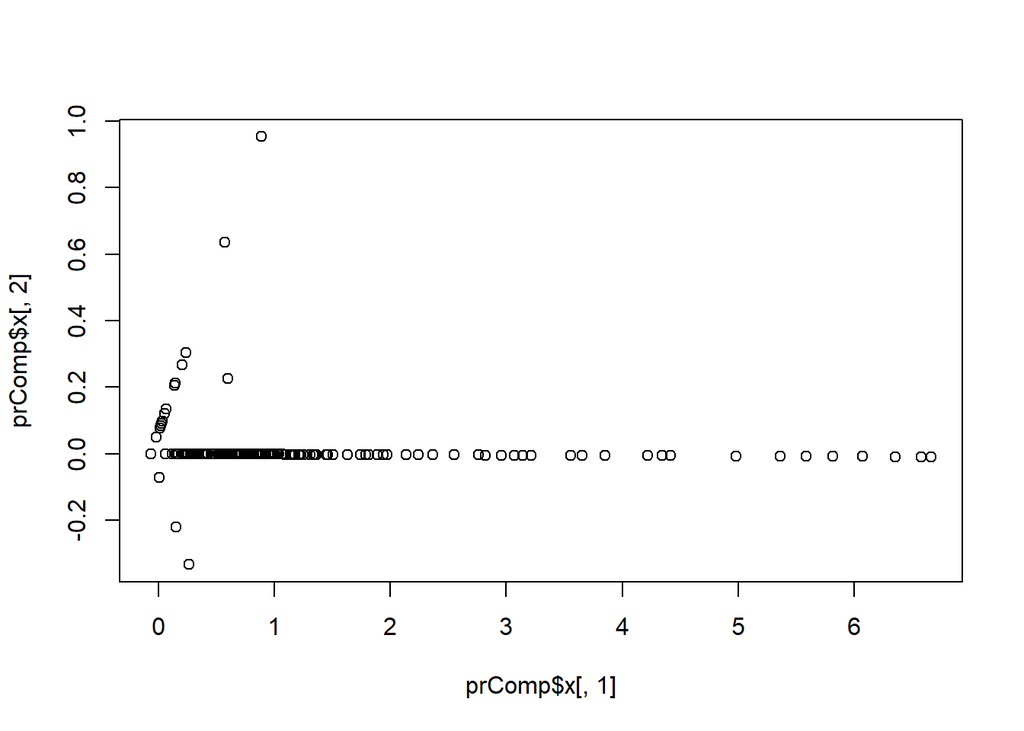

```r
library(kernlab)
data(spam)
smallSpam <- spam[,c(32,34)]
prComp <- prcomp(smallSpam)
plot(prComp$x[,1], prComp$x[,2])
```

```r
prComp$rotation
```

```
##              PC1        PC2
## num857 0.7061498 -0.7080625
## num415 0.7080625  0.7061498
```

Consider more variables: all the spam dataset.

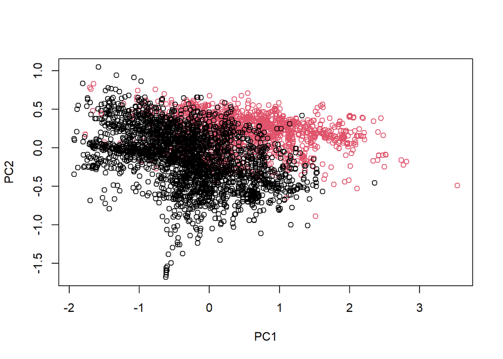

```r
typeColor <- ((spam$type=="spam")*1+1)
prComp <- prcomp(log10(spam[,-58]+1))
plot(prComp$x[,1], prComp$x[,2], col = typeColor, xlab = "PC1", ylab = "PC2")
```

This can be done using `caret`

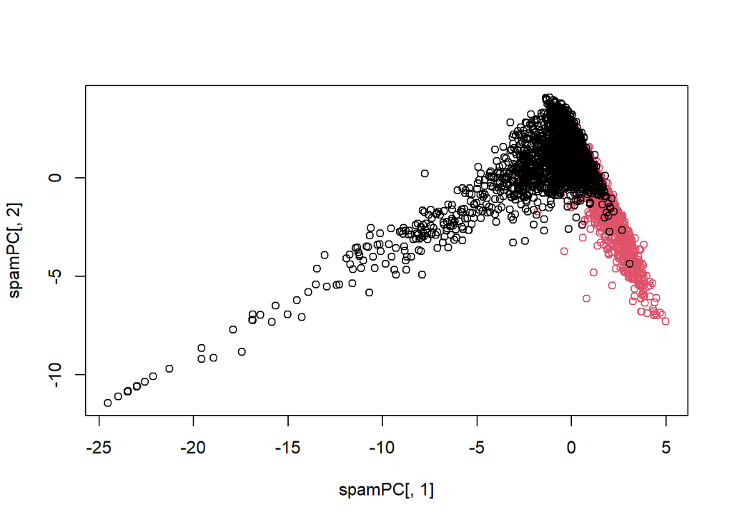

```r
preProc <- preProcess(log10(spam[,-58]+1), method = "pca", pcaComp = 2)
spamPC <- predict(preProc, log10(spam[,-58]+1))
plot(spamPC[,1], spamPC[,2], col = typeColor)
```

```r
preProc <- preProcess(log10(training[,-58]+1), method = "pca", pcaComp=2)
trainPC <- predict(preProc, log10(training[,-58]+1))
modelFit <- train(x = trainPC, y = training$type, method = "glm")

testPC <- predict(preProc, log10(testing[,-58]+1))
confusionMatrix(testing$type, predict(modelFit, testPC))
```

```
## Confusion Matrix and Statistics
##
##           Reference
## Prediction nonspam spam
##    nonspam     645   52
##    spam         73  380
##
##                Accuracy : 0.8913
##                  95% CI : (0.8719, 0.9087)
##     No Information Rate : 0.6243
##     P-Value [Acc > NIR] : < 2e-16
##
##                   Kappa : 0.7705
##
##  Mcnemar's Test P-Value : 0.07364
##
##             Sensitivity : 0.8983
##             Specificity : 0.8796
##          Pos Pred Value : 0.9254
##          Neg Pred Value : 0.8389
##              Prevalence : 0.6243
##          Detection Rate : 0.5609
##    Detection Prevalence : 0.6061
##       Balanced Accuracy : 0.8890
##
##        'Positive' Class : nonspam
##
```

An alternative:

```r
modelFit2 <- train(type ~., method = "glm", preProcess = "pca", data = training)
confusionMatrix(testing$type, predict(modelFit2, testing))
```

```
## Confusion Matrix and Statistics
##
##           Reference
## Prediction nonspam spam
##    nonspam     658   39
##    spam         50  403
##
##                Accuracy : 0.9226
##                  95% CI : (0.9056, 0.9374)
##     No Information Rate : 0.6157
##     P-Value [Acc > NIR] : <2e-16
##
##                   Kappa : 0.8372
##
##  Mcnemar's Test P-Value : 0.2891
##
##             Sensitivity : 0.9294
##             Specificity : 0.9118
##          Pos Pred Value : 0.9440
##          Neg Pred Value : 0.8896
##              Prevalence : 0.6157
##          Detection Rate : 0.5722
##    Detection Prevalence : 0.6061
##       Balanced Accuracy : 0.9206
##
##        'Positive' Class : nonspam
##
```

Final thoughts on PC

- Most useful on linear-type models.
- Can make it harder to interpret predictors.
- Watch out for outliers!
  - Transform first (with logs/Box Cox)
  - Plot predictors to identify problems
- For more info see: [Elements of Statistical Learning](http://statweb.stanford.edu/~tibs/ElemStatLearn/)

# Predicting with regression

## Key ideas

- Fit a simple regression model
- Plug in new covariates and multiply by the coefficients
- Useful when the linear model is (nearly) correct.
- **Pros**
  - Easy to implement
  - Easy to interpret
- **Cons**
  - Often poor performance in non-linear settings

## Example: Old Faithful eruptions

```r
library(caret)
data(faithful)
set.seed(333)

inTrain <- createDataPartition(y = faithful$waiting, p = 0.5, list = FALSE)
trainFaith <- faithful[inTrain,]
testFaith <- faithful[-inTrain,]
head(trainFaith)
```

```
##   eruptions waiting
## 1     3.600      79
## 3     3.333      74
## 5     4.533      85
## 6     2.883      55
## 7     4.700      88
## 8     3.600      85
```

Check if a linear model is suitable

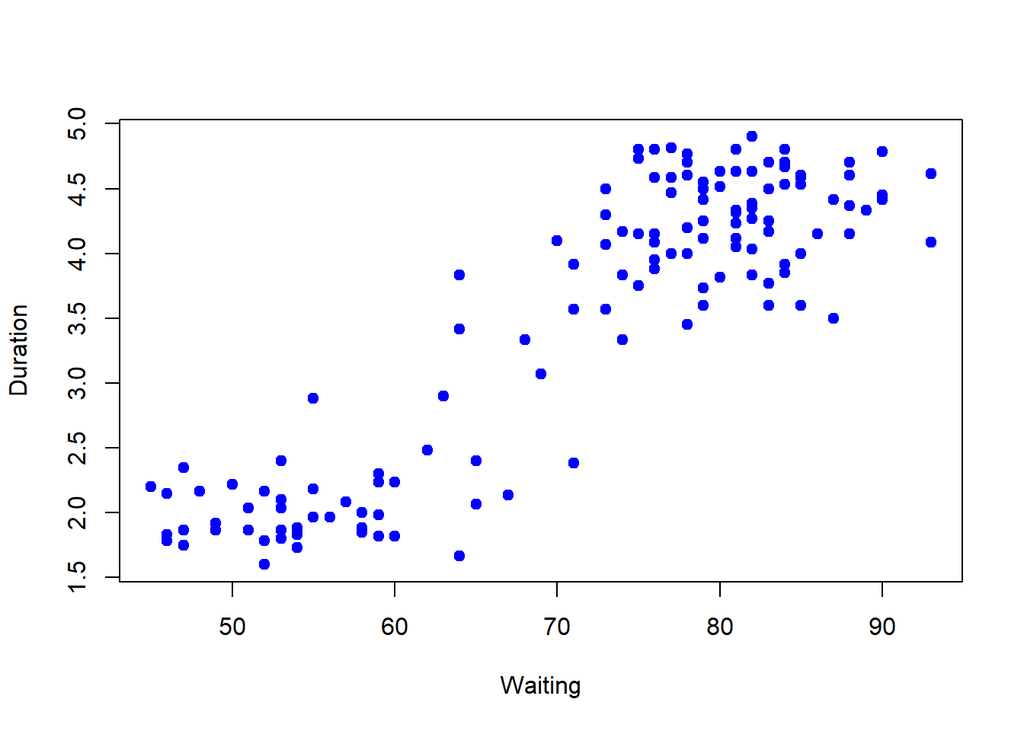

```r
plot(trainFaith$waiting, trainFaith$eruptions, pch = 19, col = "blue", xlab = "Waiting", ylab = "Duration")
```

```r
lm1 <- lm(eruptions ~ waiting, data = trainFaith)
summary(lm1)
```

```
##
## Call:
## lm(formula = eruptions ~ waiting, data = trainFaith)
##
## Residuals:
##      Min       1Q   Median       3Q      Max
## -1.26990 -0.34789  0.03979  0.36589  1.05020
##
## Coefficients:
##              Estimate Std. Error t value Pr(>|t|)
## (Intercept) -1.792739   0.227869  -7.867 1.04e-12 ***
## waiting      0.073901   0.003148  23.474  < 2e-16 ***
## ---
## Signif. codes:  0 '***' 0.001 '**' 0.01 '*' 0.05 '.' 0.1 ' ' 1
##
## Residual standard error: 0.495 on 135 degrees of freedom
## Multiple R-squared:  0.8032, Adjusted R-squared:  0.8018
## F-statistic:   551 on 1 and 135 DF,  p-value: < 2.2e-16
```

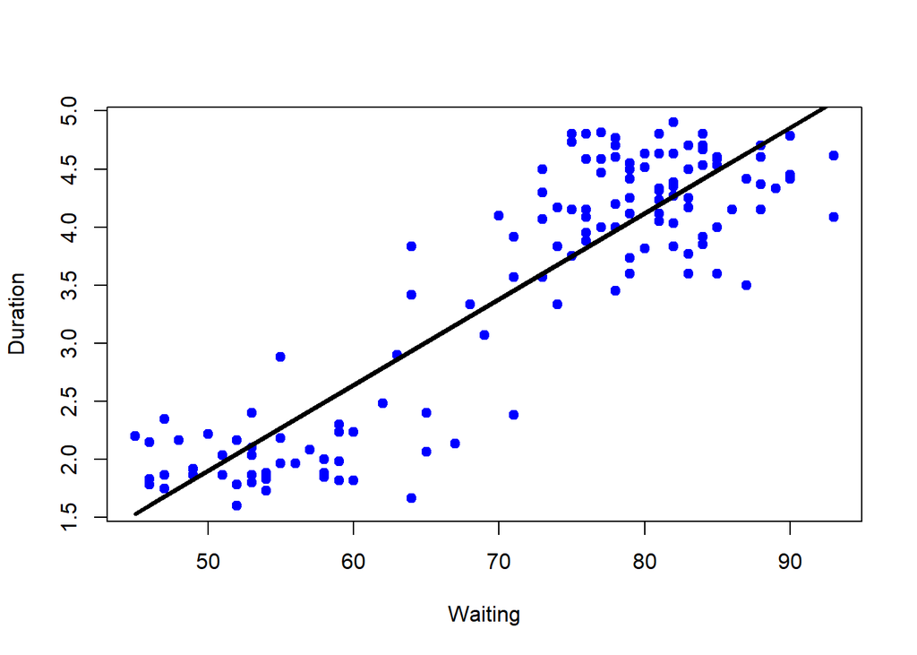

```r
plot(trainFaith$waiting, trainFaith$eruptions, pch = 19, col = "blue", xlab = "Waiting", ylab = "Duration")
lines(trainFaith$waiting, lm1$fitted.values, lwd = 3)
```

Predict a new value: use the coefficients or use the `predict` function. For instance, assume $waiting = 80$

```r
coef(lm1)[1] + coef(lm1)[2]*80
```

```
## (Intercept)
##    4.119307
```

```r
newdata <- data.frame(waiting = 80)
predict(lm1,newdata)
```

```
##        1
## 4.119307
```

```r
newdata <- data.frame(waiting = c(20,60,80))
predict(lm1,newdata)
```

```
##          1          2          3
## -0.3147277  2.6412957  4.1193074
```

## Plot predictions - training and test

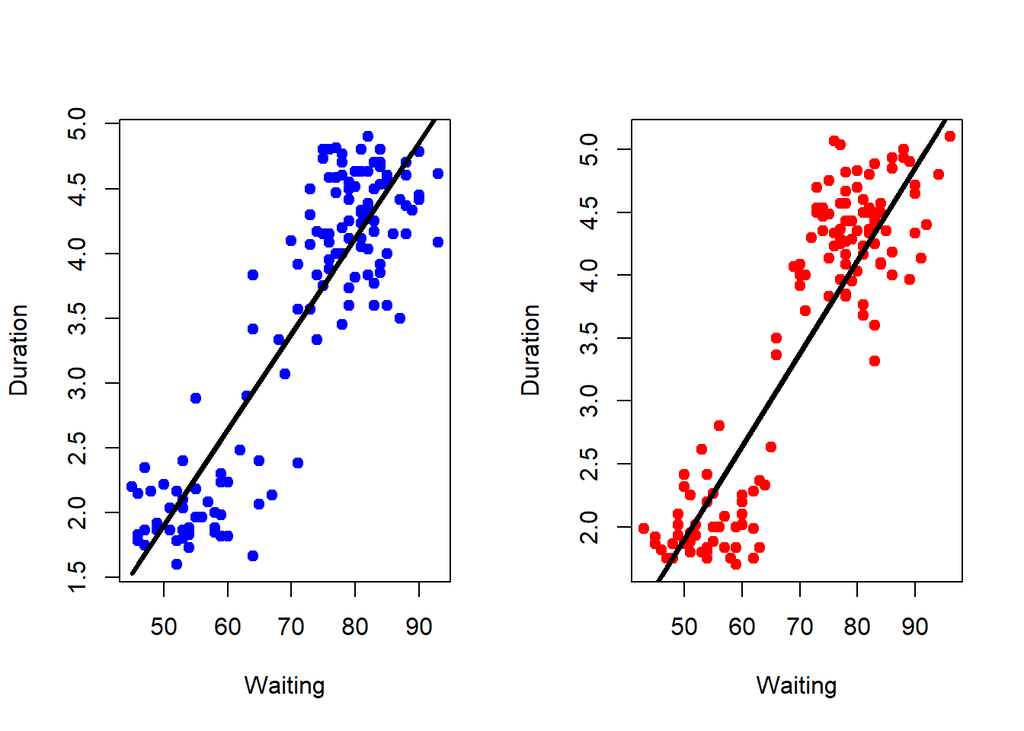

```r
par(mfrow = c(1,2))
plot(trainFaith$waiting, trainFaith$eruptions, pch = 19, col = "blue", xlab = "Waiting", ylab = "Duration")
lines(trainFaith$waiting, predict(lm1), lwd = 3)
plot(testFaith$waiting, testFaith$eruptions, pch = 19, col = "red", xlab = "Waiting", ylab = "Duration")
lines(testFaith$waiting, predict(lm1, newdata = testFaith), lwd = 3)
```

## Get the training and test set errors

```r
# Calculate the RMSE on training
sqrt(sum((lm1$fitted.values - trainFaith$eruptions)^2))
```

```
## [1] 5.75186
```

```r
# Calculate the RMSE on test
sqrt(sum((predict(lm1,newdata = testFaith) - testFaith$eruptions)^2))
```

```
## [1] 5.838559
```

## Prediction intervals

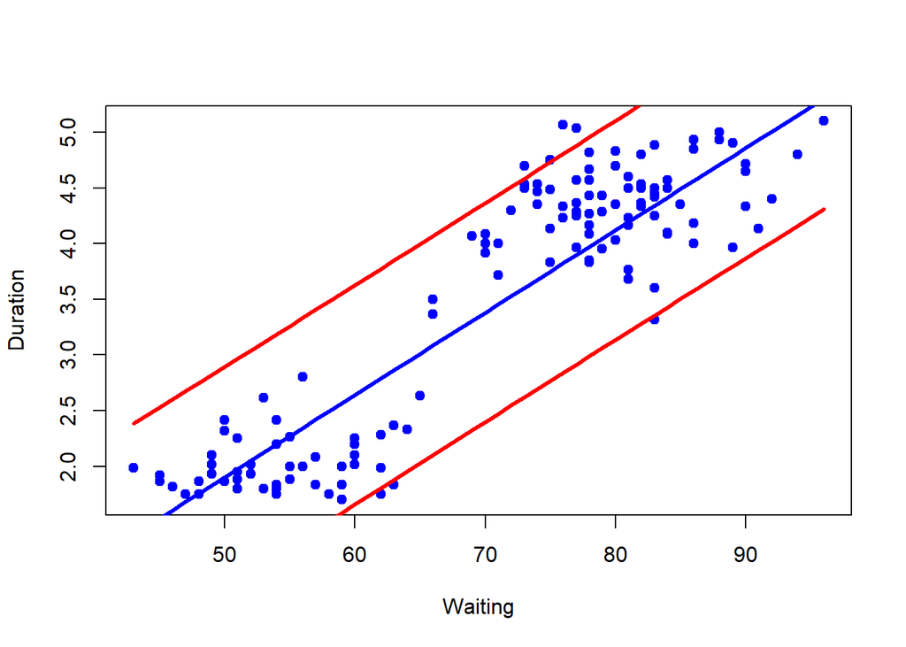

```r
pred1 <- predict(lm1, newdata = testFaith, interval = "prediction")
ord <- order(testFaith$waiting)
plot(testFaith$waiting, testFaith$eruptions, pch = 19, col = "blue", xlab = "Waiting", ylab = "Duration")
matlines(testFaith$waiting[ord], pred1[ord,], type = "l", col = c("blue","red","red"), lty = c(1,1,1), lwd = 3)
```

## Same process with caret

```r
modelFit3 <- train(eruptions ~ waiting, data = trainFaith, method = "lm")
summary(modelFit3$finalModel)
```

```
##
## Call:
## lm(formula = .outcome ~ ., data = dat)
##
## Residuals:
##      Min       1Q   Median       3Q      Max
## -1.26990 -0.34789  0.03979  0.36589  1.05020
##
## Coefficients:
##              Estimate Std. Error t value Pr(>|t|)
## (Intercept) -1.792739   0.227869  -7.867 1.04e-12 ***
## waiting      0.073901   0.003148  23.474  < 2e-16 ***
## ---
## Signif. codes:  0 '***' 0.001 '**' 0.01 '*' 0.05 '.' 0.1 ' ' 1
##
## Residual standard error: 0.495 on 135 degrees of freedom
## Multiple R-squared:  0.8032, Adjusted R-squared:  0.8018
## F-statistic:   551 on 1 and 135 DF,  p-value: < 2.2e-16
```

## Notes and further reading

- Regression models with multiple covariates can be included
- Often useful in combination with other models
- [Elements of statistical learning](http://www-stat.stanford.edu/~tibs/ElemStatLearn/)
- [Modern applied statistics with S](http://www.amazon.com/Modern-Applied-Statistics-W-N-Venables/dp/0387954570)
- [Introduction to statistical learning](http://www-bcf.usc.edu/~gareth/ISL/)

# Predicting with regression multiple covariates

Let’s take a look at one example. We use the `Wage` dataset and remove the variable `logwage` because we want to predict it using the rest of variables.

```r
library(ISLR)
library(ggplot2)
library(caret)
data(Wage)
Wage <- subset(Wage, select = -c(logwage))
summary(Wage)
```

```
##       year           age                     maritl           race
##  Min.   :2003   Min.   :18.00   1. Never Married: 648   1. White:2480
##  1st Qu.:2004   1st Qu.:33.75   2. Married      :2074   2. Black: 293
##  Median :2006   Median :42.00   3. Widowed      :  19   3. Asian: 190
##  Mean   :2006   Mean   :42.41   4. Divorced     : 204   4. Other:  37
##  3rd Qu.:2008   3rd Qu.:51.00   5. Separated    :  55
##  Max.   :2009   Max.   :80.00
##
##               education                     region               jobclass
##  1. < HS Grad      :268   2. Middle Atlantic   :3000   1. Industrial :1544
##  2. HS Grad        :971   1. New England       :   0   2. Information:1456
##  3. Some College   :650   3. East North Central:   0
##  4. College Grad   :685   4. West North Central:   0
##  5. Advanced Degree:426   5. South Atlantic    :   0
##                           6. East South Central:   0
##                           (Other)              :   0
##             health      health_ins        wage
##  1. <=Good     : 858   1. Yes:2083   Min.   : 20.09
##  2. >=Very Good:2142   2. No : 917   1st Qu.: 85.38
##                                      Median :104.92
##                                      Mean   :111.70
##                                      3rd Qu.:128.68
##                                      Max.   :318.34
##
```

Create the train and test sets

```r
inTrain <- createDataPartition(y = Wage$wage, p = 0.7, list = FALSE)
training <- Wage[inTrain,]
testing <- Wage[-inTrain,]
dim(training)
```

```
## [1] 2102   10
```

```r
dim(testing)
```

```
## [1] 898  10
```

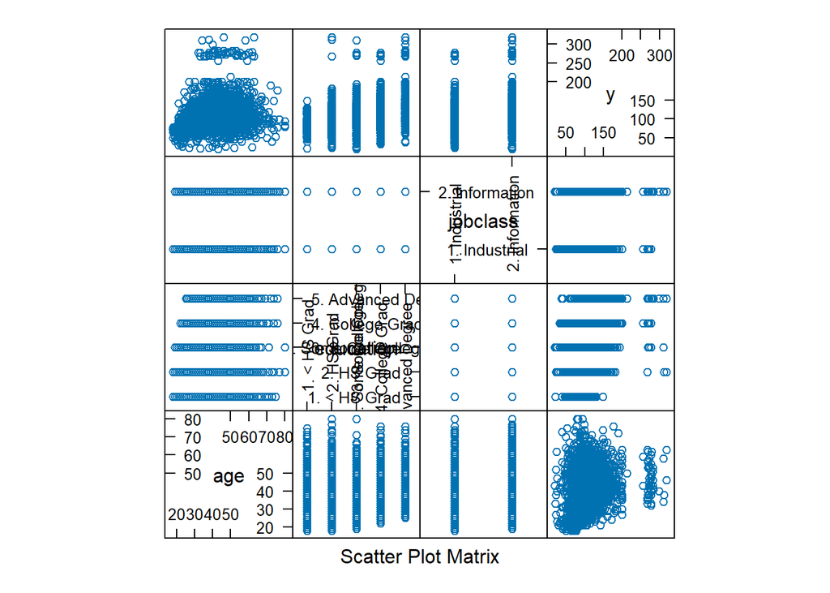

```r
featurePlot(x = training[,c("age", "education", "jobclass")], y = training$wage, plot = "pairs")
```

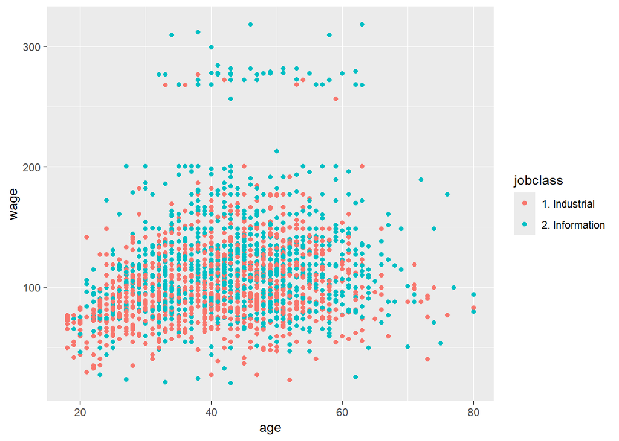

```r
qplot(age, wage, data = training, colour = jobclass)
```

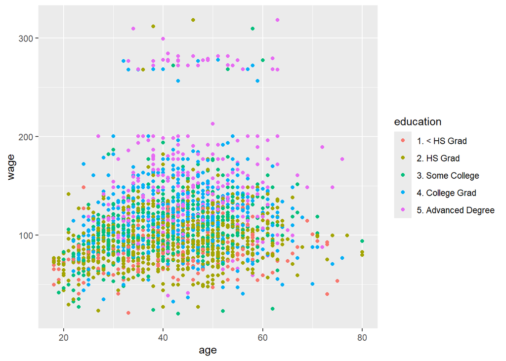

```r
qplot(age, wage, data = training, colour = education)
```

We can see that eduaction and job class might have effect on the variable `wage`. Therefore, we can fit a linear model.

$$Y = \beta_0 + \beta_1 X_1 + \beta_2 X_2 + \left(\beta_3 X_3 +
\beta_4 X_4 + \beta_5 X_5 + \beta_6 X_6\right)$$

```r
modFit <- train(wage ~ age + jobclass + education, method = "lm", data = training)
finMod <- modFit$finalModel
print(modFit)
```

```
## Linear Regression
##
## 2102 samples
##    3 predictor
##
## No pre-processing
## Resampling: Bootstrapped (25 reps)
## Summary of sample sizes: 2102, 2102, 2102, 2102, 2102, 2102, ...
## Resampling results:
##
##   RMSE      Rsquared  MAE
##   35.79066  0.248127  24.68782
##
## Tuning parameter 'intercept' was held constant at a value of TRUE
```

```r
print(finMod)
```

```
##
## Call:
## lm(formula = .outcome ~ ., data = dat)
##
## Coefficients:
##                   (Intercept)                            age
##                       61.1007                         0.5098
##      `jobclass2. Information`          `education2. HS Grad`
##                        5.2087                        11.8644
##    `education3. Some College`     `education4. College Grad`
##                       22.7759                        36.3843
## `education5. Advanced Degree`
##                       62.8906
```

## Diagnostics

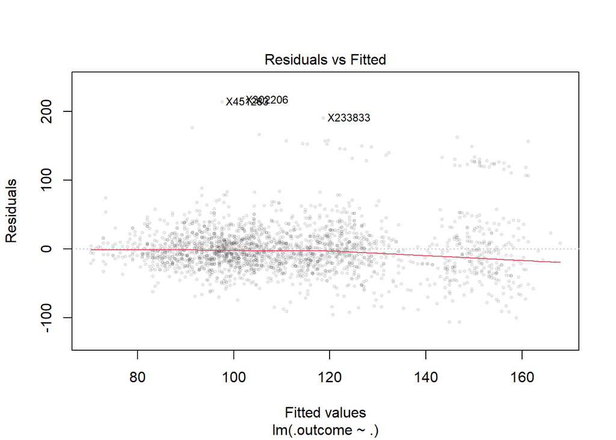

```r
plot(finMod, 1, pch=19, cex = 0.5, col = "#00000010")
```

We can see what happens when we colour by variables not included in the model:

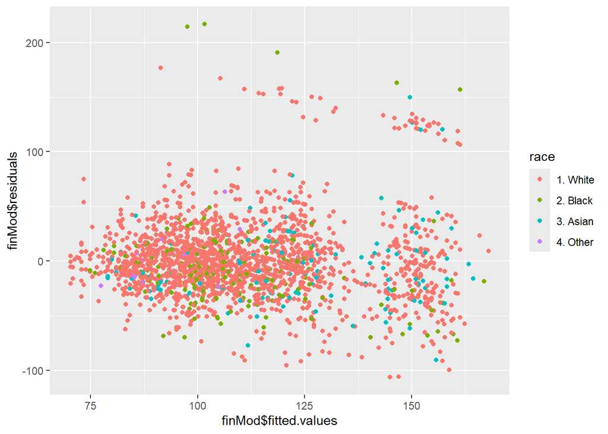

```r
qplot(finMod$fitted.values, finMod$residuals, colour = race, data = training)
```

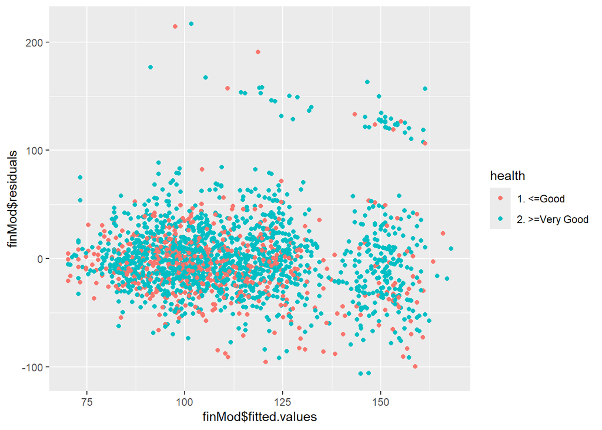

```r
qplot(finMod$fitted.values, finMod$residuals, colour = health, data = training)
```

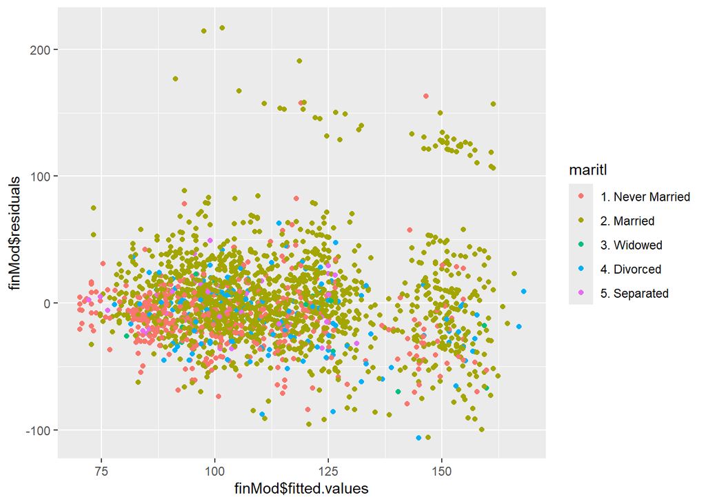

```r
qplot(finMod$fitted.values, finMod$residuals, colour = maritl, data = training)
```

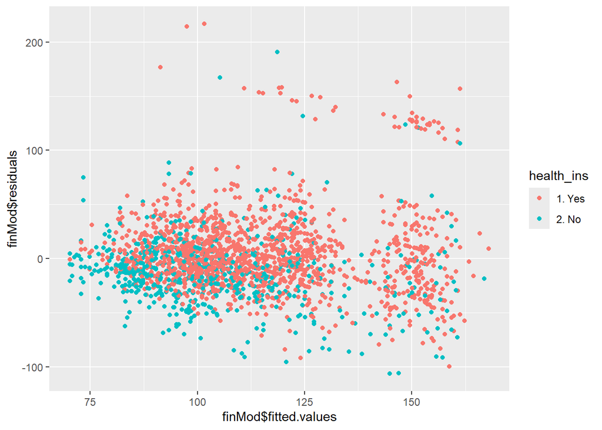

```r
qplot(finMod$fitted.values, finMod$residuals, colour = health_ins, data = training)
```

## Plot residuals by index

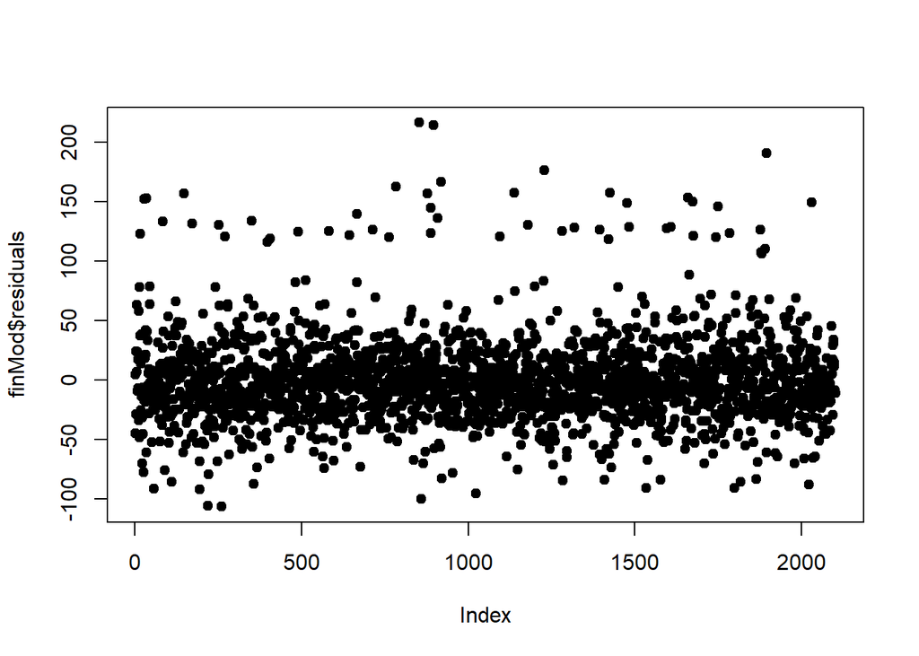

```r
plot(finMod$residuals, pch = 19)
```

## Predicted versus truth in test set

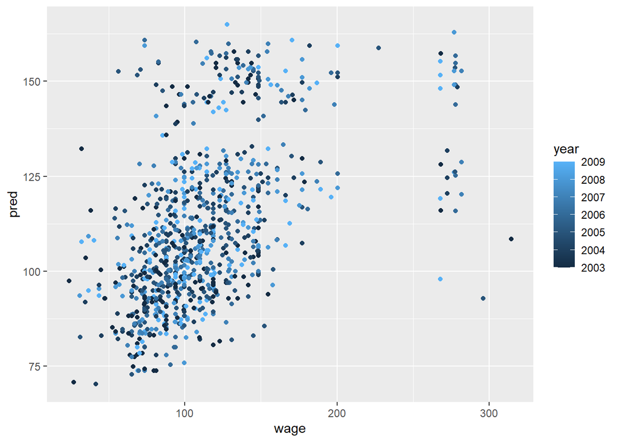

```r
pred <- predict(modFit, testing)
qplot(wage, pred, colour = year, data = testing)
```

## Using all covariates

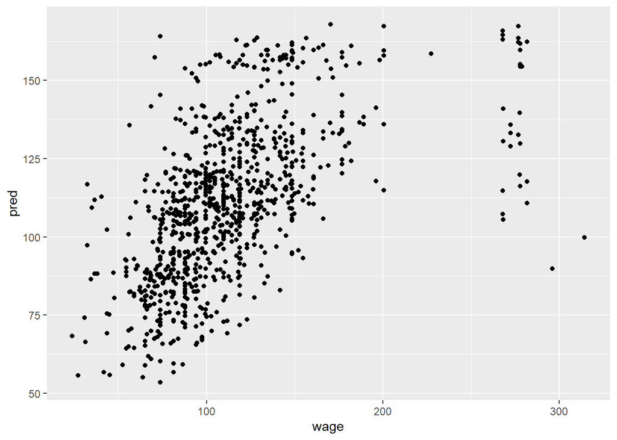

```r
modFitAll <- train(wage ~ ., data = training, method = "lm")
pred <- predict(modFitAll, testing)
qplot(wage, pred, data = testing)
```